# Higgs Boson identification

Arturo Prieto Tirado

7/12/2020

## Introduction

The way one checks if particle physics theories adjust to reality is by doing collision experiments in accelerators. For example, if we make two protons collide, very different kinds of particles will come out. The theory gives us the probability that a certain event (particle production) will happen, so that we know the distribution we should expect. What one does then is to compare the experiment’s results with the current known theory distribution (this is called the “background”), which will be our null hypothesis, with the number of events one would expect to happen if the alternative theory was true. These new events are called “signal”, and thus we will expect to see in the experiment signal+background. However, in the real experiment, we don’t know the origin of the particle, but we do measure other magnitudes related to its dynamics. So, it would be very useful to have a model that can identify one of these events from real data. In order to do this, we are going to use data from simulations. These events have been created from theory simulations (so that we know if they belong to signal or background) and then simulated the kinematic variables one would measure in the accelerator. The model we will get here is specific for the Higgs boson production decaying into tau tau. So, the background are processes anything$\rightarrow \tau^+\tau^-$ while the signal is Higgs $\rightarrow \tau^+\tau^-$.

The dataset was taken from http://opendata.cern.ch/record/328 and variables that we are going to use can be summarized in the following groups.

- General magnitudes: These are magnitudes like the mass of the Higgs boson candidate (DER_mass_MMC), the missing transverse energy in the detector, associated to neutrinos we cannot measure, (PRI_met), its angle (PRI_met_phi) and the total transverse energy (PRI_met_sumet) as well as the total momentum (DER_pt_tot, DER_sum_pt). Since the nuclei are extended objects, there are other variables named “centrality” that account for the degree of overlap of the nuclei in the collision. DER_met_phi_centrality and DER_lep_eta_centrality reflect eta and met as function of the centrality.
- Jets: Jets are cascades of particles (hadrons) that originate from strong interaction (QCD). We can find a certain number of jets (PRI_jet_num), with a given total momentum , which is a magnitude similar to the energy, (PRI_jet_all_pt) and product and diferences of pseudorapidities (DER_prodeta_jet_jet,DER_deltaeta_jet_jet). The individual characteristics of the most important jet and the second, leading and subleading jets, respectively, are also taken into account: their momentum (PRI_jet_leading_pt, PRI_jet_subleading_pt), their pseudorapidity, a measure of the angle with respect to the beam axis, (PRI_jet_leading_eta, PRI_jet_subleading_eta) and their angle with respect to the axis perpendicular to the beam (PRI_jet_leading_phi, PRI_jet_subleading_phi).
- Leptons (electron, muon and tau): The other kind of particles apart from the Higgs boson, jets and neutrinos (missing transverse energy) that we measure are leptons, existing electron, muon and tau, with the tau being the key one, as stated before, and the others being just residuals of the disintegration process. Similarly to the jets, we can measure their momentum (DER_pt_h, DER_pt_ratio_lep_tau, PRI_tau_pt, PRI_lep_pt), pseudorapidity (DER_deltar_tau_lep, PRI_tau_eta, PRI_lep_eta), phi angle (PRI_tau_phi, PRI_lep_phi), mass (DER_mass_vis) and transverse mass (DER_mass_transverse_met_lep).

## Pre-process and analysis of the data set

The data have an important problem, and that is that the jet variables (except the number of jets) are only defined when there are jets. We can think of putting the momentum(energy) variables to 0 when there is no jet, which would make sense. However, the angle, pseudorapidity and the rest don’t make much sense, since their whole range is already covered by real cases. Any angle we search for, there is a real jet that can have it, so we cannot assign a number to substitute that NA. On the other hand, these NAs can’t be replaced by imputation of missing values since any random value would not make physical sense, as has just been explained. A possible solution would be to take these variables as categorical variables such as “no jet”, “low value” or “high value”. This was attempted, but it added more noise to the analysis, resulting in worse predictive power. So, best approach and the one going to be presented here is the one getting rid of the jet undefined variables except the jet momenta, that are set to 0 for the NAs.

Also, there were some real missing values in the Higgs boson mass variable that were imputed using the library mice and the “norm” method, which applies linear bayesian regression, valid for numeric variables, as is the case for the Higgs boson candidate mass.

A first visualization of the variables is shown in the following kernel densities for quantitatives and barplot for the label: signal or background.

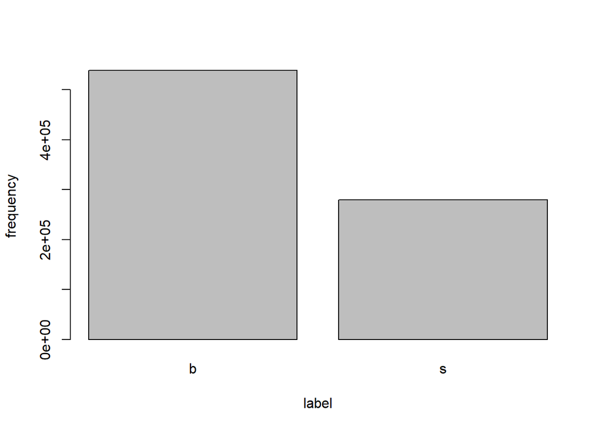

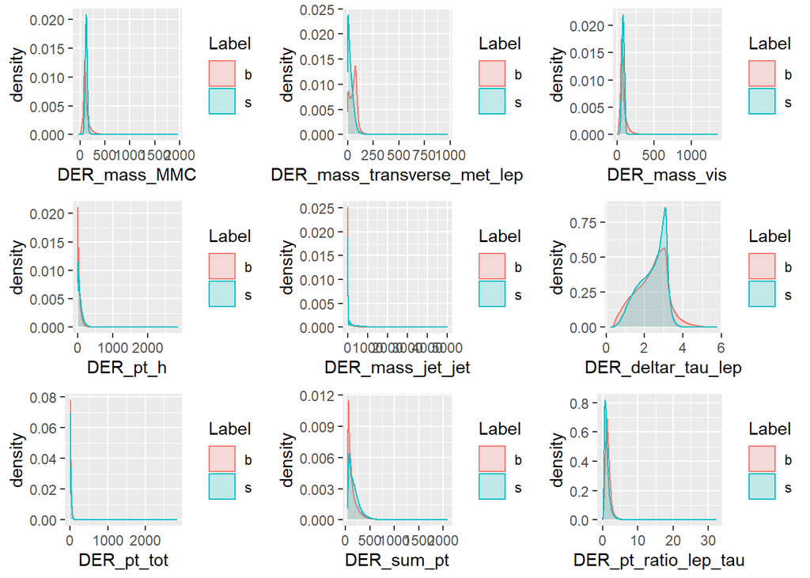

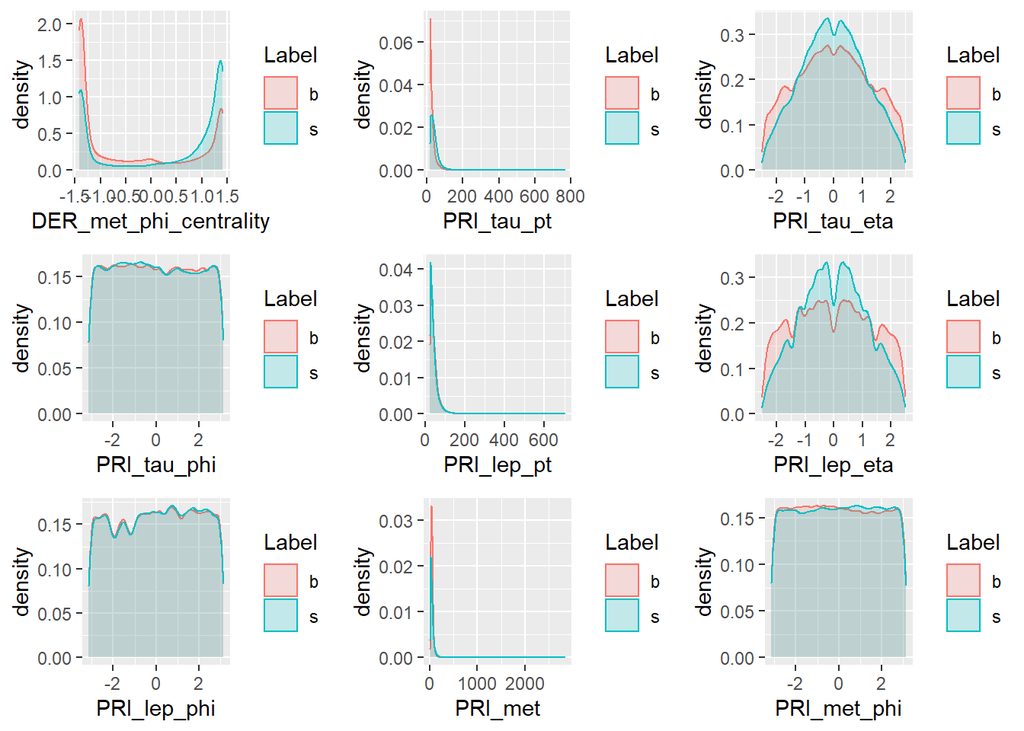

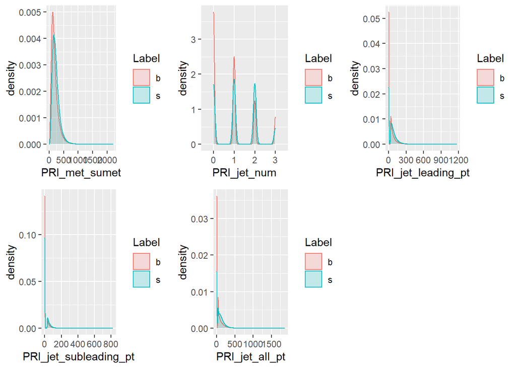

Another step that can be taken now is to analyze the correlation between all the variables and the label. Since it is a dichotomous categorical variable, we can use the point biserial correlation for its correlation with numerical variables and Cramer’s V between categorical ones (number of jets).

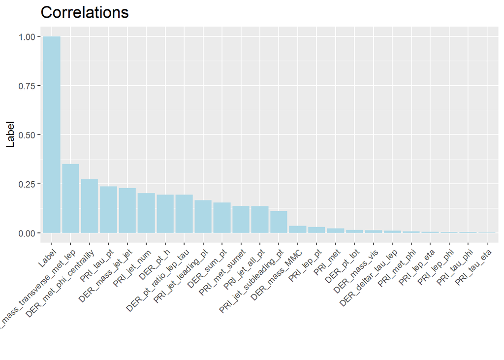

## Modelling using Statistical Tools

The first goal is to create a model that explains what is happening. That is, the main contributors to being in signal or background. Afterwards, we will create a model that focuses on prediction, but now our goal is simplicity and explainability.

Since this is binary classification, we can try with logistic regression. To focus on interpretation, we could try the model with the most correlated variable or any number of them, we will do it with 4. However, one should keep in mind that the correlation only tells linear relations, not more complex ones.

```
##
## Call:
## vglm(formula = fmla, family = multinomial(refLevel = 1), data = trainData)
##
## Coefficients:
##                               Estimate Std. Error z value Pr(>|z|)
## (Intercept)                 -5.471e-01  8.576e-03  -63.79   <2e-16 ***
## DER_mass_transverse_met_lep -2.156e-02  1.154e-04 -186.78   <2e-16 ***
## DER_met_phi_centrality       1.715e-01  2.877e-03   59.62   <2e-16 ***
## PRI_tau_pt                   1.832e-02  1.584e-04  115.62   <2e-16 ***
## DER_mass_jet_jet             1.103e-03  1.298e-05   84.97   <2e-16 ***
## ---
## Signif. codes:  0 '***' 0.001 '**' 0.01 '*' 0.05 '.' 0.1 ' ' 1
##
## Name of linear predictor: log(mu[,2]/mu[,1])
##
## Residual deviance: 617160.1 on 572762 degrees of freedom
##
## Log-likelihood: -308580.1 on 572762 degrees of freedom
##
## Number of Fisher scoring iterations: 5
##
## No Hauck-Donner effect found in any of the estimates
##
##
## Reference group is level  1  of the response
```

We can see that the variables are all very significative. Their interpretation is that, for every one unit change in each of the variables, the log odds of being a signal event versus a background event (the reference one) increases or decreases by the coefficient.

We can take the exponential of the coefficients to get the odds.

```
##                 (Intercept) DER_mass_transverse_met_lep
##                   0.5786353                   0.9786702
##      DER_met_phi_centrality                  PRI_tau_pt
##                   1.1871205                   1.0184853
##            DER_mass_jet_jet
##                   1.0011036
```

The same can be seen in the other variables, phi centrality and tau pt, the signal distribution spans higher values than the background so, if we had an unknown high value, we would associate it with signal intuitively. The logit model tells us the same, because the odds of these two variables are greater than one In the same way, lower values of transverse missing transverse energy are associated with signal, in agreement with the plot as well.

In conclusion, the logit model seems more or less consistent and gives a nice and simple interpretation of the main variables entering into play to describe the physics phenomena behind the data, consistent with the shape of the distributions observed when pre analyzing the data. A possible interpretation is that the kind of interaction plays the most important role. The missing transverse energy (mass_transverse_met) accounts for an excedent in energy, usually associated to neutrinos, related with weak force interaction. The mass_jet_jet is related to the energy of jets, which are cascades of particles produced by strong force interaction (QCD). Following this way of reasoning, it makes sense that the distance of interaction given by the centrality would also be different for each interaction type. Therefore, one of the main drivers for classification is the type of interaction. The other main driver is the $\tau$ momentum, where the model tells us there is a key difference between the taus produced by a Higgs and the ones produced by background processes.

One thing to take into account is that having enough “s” events supports a claim for discovery, therefore, it is not an error we should tolerate because we want to be really sure that the “new physics” events are real. One doesn’t want to claim that has discovered a new particle to then see it was all a fake. On the other hand, classifying “b” as “s” might make a real discovery need more work, but we can take it as a conservative approach. Then, we should try with change of threshold. This value could be tuned as a hyperparameter if we knew the exact cost matrix. However, that we don’t know.

When talking about these kind of errors, it is useful to do so in terms of two parameters called “specificity” and "sensitivity, defined as follows:
$$\begin{equation}
Specificity=\frac{\text{real s classified as s}}{\text{real s classified as s}+ \text{real s predicted as b}}
\end{equation}$$

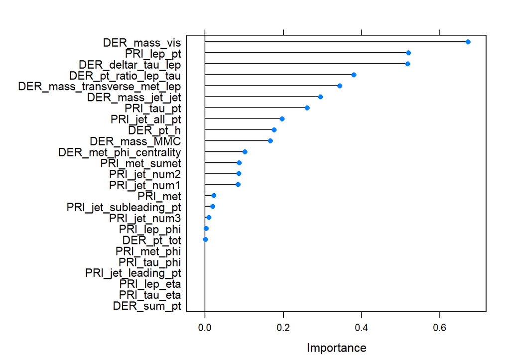

Finally, we can try using Bayes classifiers: Naive Bayes, QDA, LDA (and their step versions). The complete results are summarized in the following table.

| Model | Accuracy | Specificity | Sensitivity |
| --- | --- | --- | --- |
| “b” model | 65.8% | 0 % | 100% |
| Simple Logistic | 70.8% | 29.9% | 92.1% |
| Logistic complete | 74.7% | 48.2% | 88.5% |
| Penalized Logistic | 75.0% | 53% | 86.4% |
| Naive Bayes | 71.9% | 52.7% | 81.9% |
| LDA | 74.6% | 52.3% | 86.1% |
| QDA | 75.7% | 63.9% | 81.9% |
| Step LDA | 69.3% | 39.8% | 84.6% |
| Step QDA | 72.1% | 61.8% | 77.5% |

## Discussion and Conclusions

On the other hand, there might be room for improvement in the NA treatment, since in the end, a lot of variables (the jet variables) were discarded and it would be useful to be able to use that information. One way would be creating categorical variables. Since the variable number of jets already exists and we want one of the categories to be “no jet” to avoid these NAs, we would need at least 3 categories, otherwise the information would already be contained in having or not a jet. The problem with this would be which threshold to apply to each of the categories “low value” and “high value”. As commented before, applying some limits looking at the distribution by eye didn’t improve the results and it introduced a bias for sure. However, this could change if using clustering techniques to create k=3 groups in the problematic variables so that we don’t need to choose the values arbitrarily. In any case, these would require a more advanced treatment of the data and, due to the size of the dataset, probably too much computational cost.

Finally, there are some Machine Learning methods, like random forests, that are able to deal with NAs, which may lead to better results. This fact will be analyzed in the next part of the project together with other ML methods.